# SDGB-7844 Homework #3

Ryan Waffle

April 1, 2020

### The USA Today Diversity Index

The USA TODAY Diversity Index is a number – on a scale from 0 to 100 – that represents the chance that two people chosen randomly from an area will be different by race and ethnicity. In more personal terms: “What is the chance that the next person I meet will be different from me?” A higher number means more diversity, a lower number, less. The index was invented in 1991 by Phil Meyer of the University of North Carolina and Shawn McIntosh of USA TODAY.

#### Exploratory Analysis

1. At what level (State, County, City) is the American Community Survey data available? How is this different than the deccenial census?

**Answer: ACS data is avaiable down to the census block group level, which is a grouping of essentially city blocks. It is also available at the census tract level, which is essentially a neighborhood. The Decennial census is available at the individual census block level. We will be using ACS data at the county level.**

2. What variable and variable codes are available to describe race and ethnicity in the US Census? Describe how these variables are represented in the data (Variables: B2001_001-B2001_006 & B03002_001-B03002_002 & B03002_012).

**Answer: The Census contains 5 main race groups: White alone (B02001_002), Black or African American Alone (B02001_003), American Indian and Alaska Native Alone (B02001_004), Asian Alone (B02001_005), and Native Hawaiin and Other Pacific Islander Alone (B02001_006). These are grouped together into the Total Estimate, B02001_001. The census also keeps a record of individuals indicating either Hispanic or Latino origin (B03002_012), or No Hispanic or Latino Origin (B03002_002). These two are grouped into the Total Figure, B03002_001. Each group features an estimated population with a margin of error.**

3. How does the American Community Survey define race and ethnicity? Is this important information to report under assumptions for your analysis?

**Answer: Race is defined as a person’s self-identification with one or more social groups. The choices are: White, Black or African American, Asian, American Indian and Alaska Native, Native Hawaiian and Other Pacific Islander, or other. Ethnicity is whether a person is of Hispanic origin or not. This is important to know because the census allows for anyone of Hispanic origin to report as any other race, which mean that many individuals can report as multiple races.**

4. Does the American Community Survey provide the margin of error for their estimates of the proportion of the prevalence of each race and ethnicity? How might this impact the validity of our results?

**Answer: Yes, each population race estimate is given a marin of error. The impact of the margin of error is dependent on the size of that margin. In some cases, the margin of error is less than 1% of the population estimate, which would likely not have a large impact on our results. In other cases, however, the margin of error may be >50% of the estimate, especially in low population estimates. This might drastically change the diversity index of a low population county, if the population estimate of one or more races is actually half or 1.5 times the population estimate.**

5. Use the *tidycensus* API to assign the race and ethnicity data for New York, New Jersey and Connecticut (at the County level) to a data frame.

```r
library(tidycensus)
library(tidyverse)

#Census API key, and saving it for later use

census_api_key("2ca8081b03f710456a7ada64fff9d7f8168837f4", install = TRUE, overwrite=TRUE)

#Loading all the acs variables to accurately view them and find the ones we need

#v18 <- load_variables(2018, "acs5", cache = TRUE)

#Creating dataframe for the three states, including all needed ACS variables based on the given codes. Pulling for NY, NJ, CT for 2018. Setting geometry = TRUE for mapping purposes later

states <- get_acs(geography = "county", variables = c(Total = "B02001_001", White_Alone = "B02001_002",
                                                      Black_or_African_American_Alone = "B02001_003", American_Indian_and_Alaska_Native_Alone ="B02001_004",
                                                      Asian_Alone = "B02001_005", Native_Hawaiian_and_Other_Pacific_Islander_Alone = "B02001_006",
                                                      Not_Hispanic_or_Latino_Total = "B03002_002", Hispanic_or_Latino_Total = "B03002_012"),
                  state = c("NY", "NJ", "CT"),
                  year = 2018,
                  geometry = TRUE)

#Subsetting the states dataframe to remove the margin of error variable.

states <- subset(states, select = c(GEOID, NAME, variable, estimate))
```

#### Computing The USA Today Diversity Index

Each of the calculations below will be done **by county** and not in aggregate.

**Step 1:**

In the current federal scheme, there are five named races – white, black/African-American, American Indian/Alaska Native, Asian and Native Hawaiian/Other Pacific Islander and an estimate for total population (B2001_001-B2001_006). Ensure that you have collected the proper data from the *tidycensus* API for these values, as well as the values for the Hispanic population (B03002_001-B03002_002 & B03002_012).

Use the *spread* function to create columns for each racial group (and the total population). Rename these columns to better reflect the data if you have not already done so.

Calculate each group’s share of the population. This is done by dividing the value for each racial column by the total population column. Create new variables for your data frame for each calculation.

$$\small RaceProportion_i = \frac{Race_i}{Total_i}$$

```r
library(dplyr)
library(scales)

#Using the spread function to manipulate our dataframe so that the different variables are now their own rows
#Also renaming the NAME column to County
#Assigning to new data frame states_race_estimates

states_race_estimates <- states %>%
  spread(variable, estimate) %>%
  rename(County = NAME)

#Using the mutate function to create new columns for the percent total for each racial group based on the formula raceproportion = race estimate / total estimate
#Assigning to new data frame states_race_new

states_race_new <- states_race_estimates %>%
  mutate(White_Alone_Pct = White_Alone / Total,
         Black_or_African_American_Alone_Pct = Black_or_African_American_Alone / Total,
         American_Indian_and_Alaska_Native_Alone_Pct = American_Indian_and_Alaska_Native_Alone / Total,
         Asian_Alone_Pct = Asian_Alone / Total,
         Native_Hawaiian_and_Other_Pacific_Islander_Alone_Pct = Native_Hawaiian_and_Other_Pacific_Islander_Alone / Total,
         Not_Hispanic_or_Latino_Pct = Not_Hispanic_or_Latino_Total / Total,
         Hispanic_or_Latino_Pct = Hispanic_or_Latino_Total / Total)
```

**Step 2:**

Take each racial group’s share of the population, square it and sum the results.

$$\small P(Racial_i) = \sum_{i=1}^{n} RaceProportion_i^2$$

The Census also includes a category called “Some other race.” Because studies show that people who check it are overwhelmingly Hispanic, that category is not used. Hispanics’ effect on diversity is calculated in Step 3.

```r
#Adding the squared percentage of each racial group.
#using the mutate function to add a new column called Probability_Racial
#Assigning to new data frame states_race_probability

states_race_probability <- states_race_new %>%
  mutate(Probability_Racial = (White_Alone_Pct^2) + (Black_or_African_American_Alone_Pct^2) + (American_Indian_and_Alaska_Native_Alone_Pct^2) + (Asian_Alone_Pct^2) + (Native_Hawaiian_and_Other_Pacific_Islander_Alone_Pct^2))
```

**Step 3:**

Because Hispanic origin is a separate Census question, the probability that someone is Hispanic or not must be figured separately. Take the Hispanic and non-Hispanic percentages of the population, square each and add them to get the chance that any two people will be Hispanic or not. Use this calculation to create a new variable in your data frame.

$$\small P(Ethnic_i) = Hispanic_i^2+ Non Hispanic_i^2$$

```r
#Squaring the percentage of Hispanic or Latino and Not Hispanic or Latino, and adding those two numbers together
#using the mutate function to add a new column called Probability_Ethnic
#Assigning to new data frame states_race_ethnic

states_race_ethnic <- states_race_probability %>%
  mutate(Probability_Ethnic = (Hispanic_or_Latino_Pct^2) + (Not_Hispanic_or_Latino_Pct^2))
```

**Step 4:**

To calculate whether two people are the same on both measures, multiply the results of the first two steps. Use this calculation to create a new column in your data frame. This is the probability that any two people are the SAME by race and ethnicity.

$$\small P(Same_i) = P(Racial_i) \times P(Ethnic_i)$$

```r
#Multiplying Probability_Racial times Probability_Ethnic
#using the mutate function to add a new column called Probability_Probability Same
#Assigning to new data frame states_race_ethnic_same

states_race_ethnic_same <- states_race_ethnic %>%
  mutate(Probability_Same = Probability_Racial * Probability_Ethnic)
```

**Step 5:**

Subtract the result from 1 to get the chance that two people are different – diverse. For ease of use, multiply the result by 100 to place it on a scale from 0 to 100. Create a new column with your USA Today Diversity Index value.

$$\small DiversityIndex_i = \Big( 1 - P(Same_i) \Big) \times 100$$

```r
#Subtracting the Probability_Same variable from 1, and multiplying by 100
#using the mutate function to add a new column called Diversiity_Index
#Assigning to new data frame diversity_index_df

diversity_index_df <- states_race_ethnic_same %>%
  mutate(Diversity_Index = (1-Probability_Same) * 100)
```

#### Geo-spatial Analysis and Visualization

Be sure to properly label your plots and axes. Points will be deducted for incorrect plot titles or axes.

6. Create a histogram of USA Today Diversity Index values. Describe the shape of the histogram in statistical terms (Hint: skewness).

**Answer: The histogram appears to be right-skewed, as it would appear the mean is to the right of the median.**

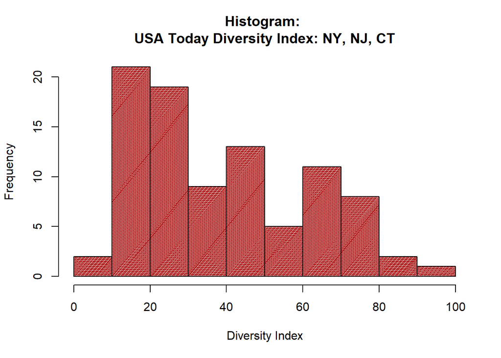

```r
#Creating figure with 1 plot: (1 row, 1 column)

par(mfrow=c(1,1))

#Creating histogram of distribution of the Diversity Index figures for the three states

hist(diversity_index_df$Diversity_Index, main = "Histogram: \nUSA Today Diversity Index: NY, NJ, CT",
     xlab = "Diversity Index", ylab = "Frequency",
     col = "firebrick", density = 75,
     angle = 50, border = "black")
```

7. Create a visualization which compares the top 10 counties and their diversity index value using ggplot2.

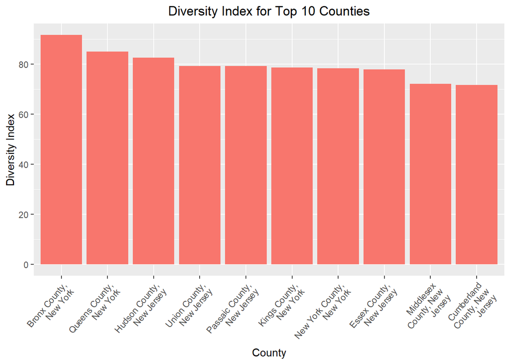

```r
library(ggplot2)
library(stringr)

# Using GG plot to show the top 10 counties and their Diversity Indicies

diversity_index_df %>%

  #Filtering only the top 10 by Diversity_Index

  top_n(10, Diversity_Index) %>%
  ggplot() +
  #Mapping the x axis as the county, and the y axis as the diversity index
  geom_col(mapping = aes(x = reorder(str_wrap(County, 16), -Diversity_Index) , y = Diversity_Index, fill = "firebrick")) +
  labs(title = "Diversity Index for Top 10 Counties", x = "County", y = "Diversity Index") +
  #Adjusting the X axis so that the county names fit on the chart
  theme(legend.position = "none", axis.text.x=element_text(angle=50,hjust=1), plot.title = element_text(hjust = 0.5)) +
  #Setting y axis in increments of 20 insteas of 25
  scale_y_continuous(breaks=seq(0,100,20))
```

8. Using the *leaflet* mapping library for R (or another mapping library of your choice), visualize the USA Today Diversity Index by county for New York, New Jersey and Connecticut.

```r
library(leaflet)
library(sf)

#Code adpted from: https://juliasilge.com/blog/using-tidycensus/
#Setting color palette for map based on the diversity index

pal <- colorNumeric(palette = "viridis",
                    domain = diversity_index_df$Diversity_Index)

diversity_index_df %>%
  st_transform(crs = "+init=epsg:4326") %>%
  #piping map data into a leaflet
  leaflet(width = "100%") %>%
  addProviderTiles(provider = "CartoDB.Positron") %>%
  #Adding map polygons
  addPolygons(stroke = FALSE,
              smoothFactor = 0,
              fillOpacity = 0.7,
              color = ~ pal(Diversity_Index)) %>%
  #Adding legend based on Diversity_Index
  addLegend("bottomright",
            pal = pal,
            values = ~ Diversity_Index,
            title = "Diversity Index",
            opacity = 1)
```

[interactive chart not shown]

9. Display the following data in the “tooltip” when mousing over your plot: USA Today Diversity Index Value and County Name.

```r
#Creating mouseover labels for county and diversity index

hover_text <- paste("County: ", diversity_index_df$County,
                    "/ USA Today Diversity Index: ", diversity_index_df$Diversity_Index)

#Using same code as the previous map, but adding label = hover_text to the polygons
diversity_index_df %>%
  st_transform(crs = "+init=epsg:4326") %>%
  leaflet(width = "100%") %>%
  addProviderTiles(provider = "CartoDB.Positron") %>%
  addPolygons(stroke = FALSE,
              smoothFactor = 0,
              fillOpacity = 0.7,
              color = ~ pal(Diversity_Index),
              #Adding hover_text as a label
              label = hover_text) %>%
  addLegend("bottomright",
            pal = pal,
            values = ~ Diversity_Index,
            title = "Diversity Index",
            opacity = 1)
```

[interactive chart not shown]

10. Does there appear to be any relationship between geography and diversity? Which state appears to be the most diverse?

**Answer: Yes, there appears to be a relationship between geography and diversity. First, counties closer to the ocean appear to be more diverse. Second, with and closer to large cities, specifically New York City, appear to be more diverse. New Jersey appears to be the most diverse state, followed by Connecticut. Although New Jersey has more low diversity counties than CT, it also has more high diversity counties. Its highest diversity counties are also higher than CT**

#### Extra Credit

11. Create a new data frame using the *tidycensus* API with data on median household income by county for New York, New Jersey and Connecticut. Join this data together with the data from New York County. Use ggplot2 (or another visualization library) to visualize the USA Today Diversity Index value and median household incomeon the same plot (Hint: try facet wrap!).

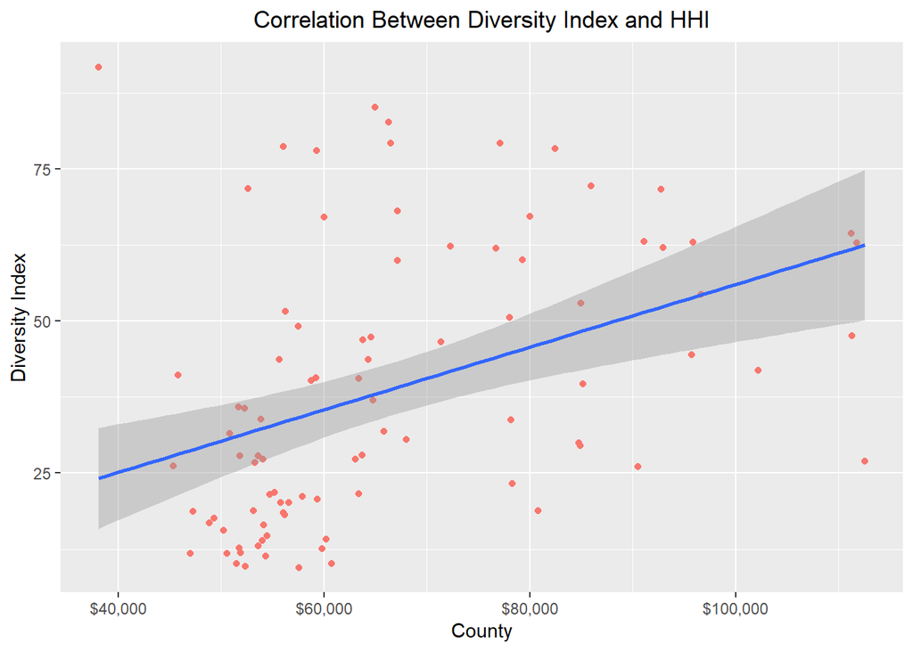

```r
#Creating new data frame removing many of the columns that will not be used

diversity_index_df_truncated <- subset(diversity_index_df, select = c(GEOID, County, Diversity_Index))

#Pulling Median Household income from acs into a new data frame, using code B19013_001

states_med_income <- get_acs(geography = "county", variables = c(Med_Income = "B19013_001"),
                  state = c("NY", "NJ", "CT"),
                  year = 2018)

#Removing Margin of error from the data frame

states_med_income <- subset(states_med_income, select = c(GEOID, NAME, variable, estimate))

#Using the spread function to make median household income its own variable, and renaming NAME to County

states_median_income <- states_med_income %>%
  spread(variable, estimate) %>%
  rename(County = NAME)

#Joining the two tables with an inner join using Dplyr

states_total <- states_median_income %>%
  inner_join(diversity_index_df_truncated, by = "GEOID")

par(mfrow=c(1,2)) # figure with 2 plots: (1 row, 2 columns)

#Plotting  scatter plot using Median Household Income vs Diversity Index
ggplot(data = states_total, aes(x = Med_Income, y = Diversity_Index)) +
  geom_point(aes(color = "firebrick", fill = "firebrick")) +
  #Adding trend line / regression line for plot
  geom_smooth(method = "lm") +
  labs(title = "Correlation Between Diversity Index and HHI", x = "County", y = "Diversity Index") +
  theme(legend.position = "none", plot.title = element_text(hjust = 0.5)) +
  #Changing x axis to be on a dollar scale
  scale_x_continuous(labels=scales::dollar_format())
```

12. Does there appear to be any relationship between median household income and diversity? How do counties differ on these two measures?

**Answer: It would appear that there is a positive linear relationship between Median Household income and Diversity. The data suggests that counties with higher Median HHI tend to be more diverse, although there are clear outliers.**